# An Introduction to **synlik**

## Introduction

The `synlik` package provides Synthetic Likelihood methods for intractable likelihoods. The package is meant to be as general purpose as possible: as long as you are able to simulate data from your model you should be able to fit it.

## Creating a **synlik** object

A `synlik` object is mainly composed of the `simulator`, which is the function that simulates data from the model of interest. In addition, it is possible to specify a function `summaries`, which transforms the data generated by `simulator` into summary statistics. The `simulator` can generate any kind of output, as long as `summaries` is able to transform it into a matrix where each row is a simulated vector of statistics. If `summaries` is not specified, then `simulator` has to output such a matrix.

Here we set-up a `synlik` object representing the Ricker map. The observations are given by \( Y_t \sim Pois(\phi N_t) \), where the hidden state has the following dynamics: \( N_t = r N_{t-1} exp( -N_{t-1} + e_t ) \). This is how we create the object:

```r
library(synlik)
ricker_sl <- synlik(simulator = rickerSimul,
                    summaries = rickerStats,
                    param = c( logR = 3.8, logSigma = log(0.3), logPhi = log(10) ),
                    extraArgs = list("nObs" = 50, "nBurn" = 50)
)
```

Here:

- `rickerSimul` and `rickerStats` are functions provided by `synlik`.
- `param` is a named vector that contains the log-parameters that will be used by `rickerSimul(param, nsim, extraArgs, ...)`.
- `extraArgs` contains additional arguments required by `rickerSimul`, see `?rickerSimul` for details.

Now we are ready to simulate data from the object:

```r
ricker_sl@data <- simulate(ricker_sl, nsim = 1, seed = 54)
```

Here `ricker_sl@data` is just a vector, but **synlik** allows the simulator to simulate any kind of object, so it is often necessary encapsulate an adequate plotting function into the object:

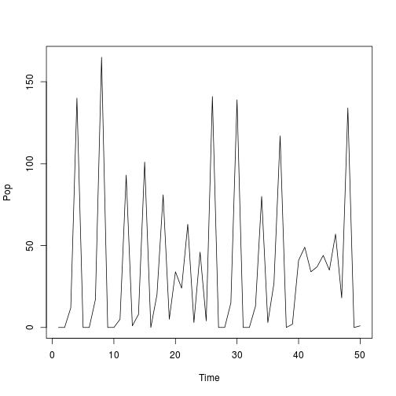

```r
ricker_sl@plotFun <- function(input, ...) plot(drop(input), type = 'l', ylab = "Pop", xlab = "Time", ...)
plot(ricker_sl)
```

If we want to simulate several datasets we simply do:

```r
tmp <- simulate(ricker_sl, nsim = 10)
dim(tmp)
```

```
## [1] 10 50
```

So far we have just simulated data, not summary statistics. In this particular example `rickerStats` needs to be passed the reference data in `ricker_sl@data` in order to be able to calculate the statistics. We can do that by using the slot `extraArgs`:

```r
ricker_sl@extraArgs$obsData <- ricker_sl@data
```

Now we are ready to simulate summary statistics:

```r
tmp <- simulate(ricker_sl, nsim = 2, stats = TRUE)
tmp
```

```
##        [,1]      [,2]      [,3]    [,4]    [,5]  [,6] [,7] [,8]   [,9]
## [1,] 0.8016 0.0005367 2.428e-05 0.03744 -0.2248 36.90   17 3181 -903.5
## [2,] 0.9022 0.0003318 1.959e-05 0.05565 -0.2073 37.38   21 3556 -864.0
##       [,10]  [,11]   [,12]  [,13]
## [1,] -370.0 -526.6   46.91 -203.2
## [2,] -930.2  547.7 -842.13  225.4
```

and to check their approximate normality:

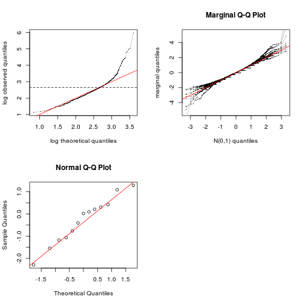

```r
checkNorm(ricker_sl)
```

## Looking at the synthetic likelihood

If we want to estimate the value of the synthetic likelihood at a certain location in the parameter space, we can do it by using the function `slik` as follows:

```r
slik(ricker_sl,
     param  = c(logR = 3.8, logSigma = log(0.3), logPhi = log(10)),
     nsim   = 1e3)
```

```
## [1] -8.744
```

We can also look at slices of this function wrt each parameter:

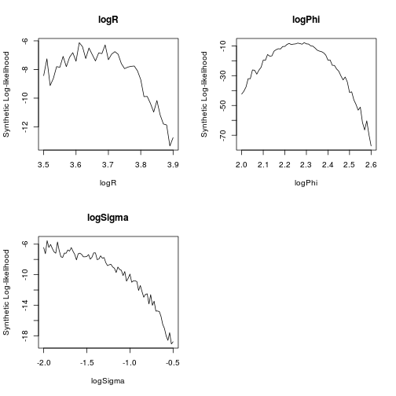

```r
slice(object = ricker_sl,
      ranges = list("logR" = seq(3.5, 3.9, by = 0.01),
                    "logPhi" = seq(2, 2.6, by = 0.01),
                    "logSigma" = seq(-2, -0.5, by = 0.02)),
      param = c(logR = 3.8, logSigma = log(0.3), logPhi = log(10)),
      nsim = 1000)
```

Finally we can have 2D slices with respect to pairs of parameters:

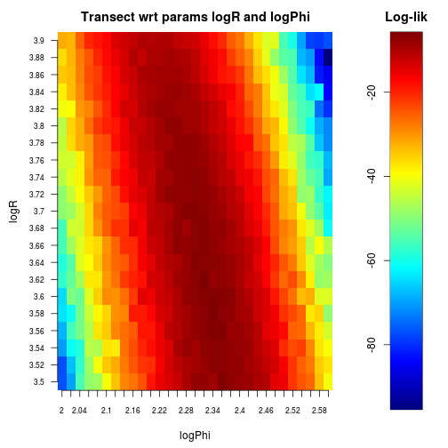

```r
slice(object = ricker_sl,
      ranges = list("logR" = seq(3.5, 3.9, by = 0.02),
                    "logPhi" = seq(2, 2.6, by = 0.02)),
      pairs = TRUE,
      param = c(logR = 3.8, logSigma = log(0.3), logPhi = log(10)),
      nsim = 1000,
      multicore = TRUE,
      ncores = 2)
```

Notice that here we have used the `multicore` option, which distributes the computation among different cores or cluster nodes. Also `slik` provides this option, but for such a simple model the time needed to set up the cluster is longer than the simulation time.

## Estimating the parameters by MCMC

The unknown model parameters can be estimated by MCMC, using the `smcmc` function. Here is an example (you might want to increase `niter`):

```r
ricker_sl <- smcmc(ricker_sl,
                   initPar = c(3.2, -1, 2.6),
                   niter = 10,
                   burn = 3,
                   priorFun = function(input, ...) sum(input),
                   propCov = diag(c(0.1, 0.1, 0.1))^2,
                   nsim = 500)
```

Notice that `priorFun` returns the log-density of the prior. If we have not reached convergence we can do some more MCMC iterations by using the `continue` generic:

```r
ricker_sl <- continue(ricker_sl, niter = 10)
```

Finally we can plot the MCMC output (here we plot a pre-computed object):

```
## [1] "Plotting the MCMC chains"
```

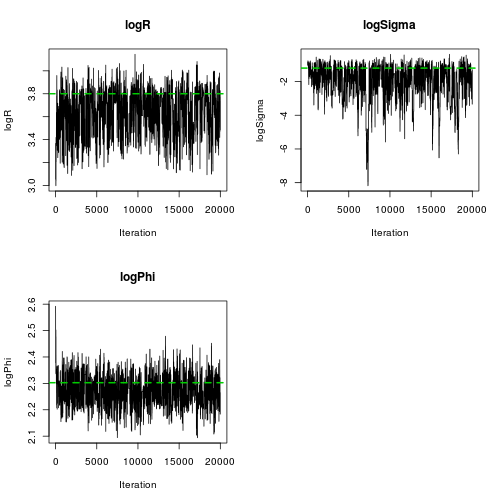

```
## Press <Enter> to see the next plot...
## [1] "The posterior densities"
```

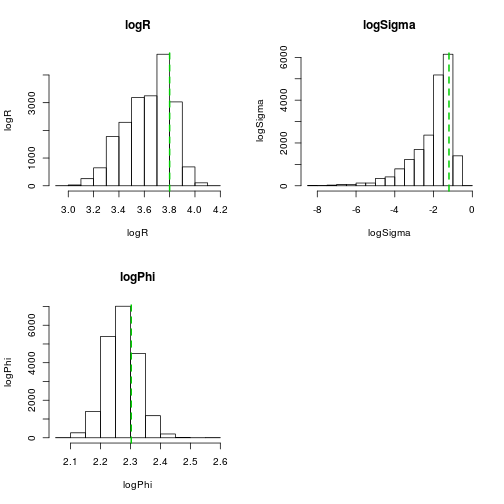

```
## Press <Enter> to see the next plot...
## [1] "Plotting the log-likelihood chain"
```

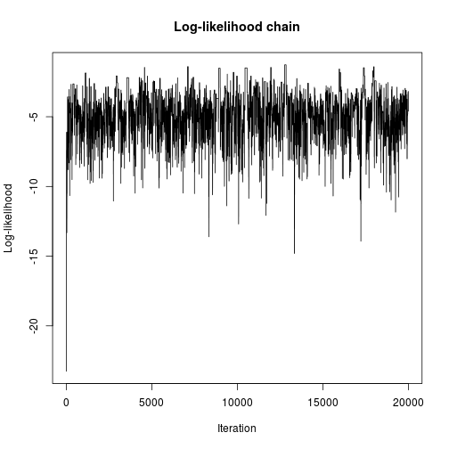

```
## Press <Enter> to see the next plot...
## [1] "Plotting correlation structure of the posterior sample"
```

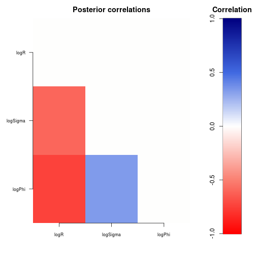

```
## Press <Enter> to see the next plot...
```

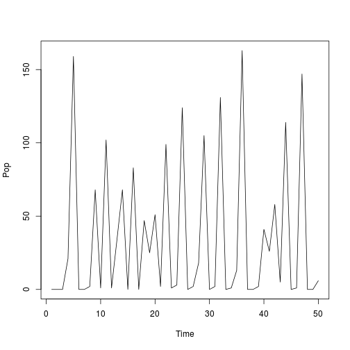

```r
data(ricker_smcmc)
addline1 <- function(parNam, ...) abline(h = ricker_smcmc@param[parNam], lwd = 2, lty = 2, col = 3)
addline2 <- function(parNam, ...) abline(v = ricker_smcmc@param[parNam], lwd = 2, lty = 2, col = 3)

plot(ricker_smcmc, addPlot1 = "addline1", addPlot2 = "addline2")
```

were we have added some lines indicating the position of the true parameters.

## Blowfly example

As a more challenging example, let us consider the Blowfly model proposed by Wood (2010): \[ N_{t} = R_t + S_t, \] where \[ R_t \sim \text{Pois}(PN_{t-\tau}e^{-\frac{N_{t-\tau}}{N_0}}e_t), \] represents delayed recruitment process, while: \[ S_t \sim \text{binom}(e^{-\delta\epsilon_t}, N_{t-1}), \] denotes the adult survival process. Finally \( e_t \) and \( \epsilon_t \) are independent gamma distributed random variables, with unit means and variances equal to \( \sigma_p^2 \) and \( \sigma_d^2 \) respectively. We start by creating a `synlik` object:

```r
blow_sl <- synlik(simulator = blowSimul,
                  summaries = blowStats,
                  param = log( c( "delta" = 0.16, "P" = 6.5, "N0" = 400, "var.p" = 0.1, "tau" = 14, "var.d" = 0.1)  ),
                  extraArgs = list("nObs" = 200, "nBurn" = 200, "steps" = 1),
                  plotFun = function(input, ...) plot(drop(input), type = 'l', ylab = "Pop", xlab = "Time", ...)
)
```

for more details see `?blow_sl`. As before we simulate data and we store it back into the object:

```r
blow_sl@data <- simulate(blow_sl, seed = 84)
blow_sl@extraArgs$obsData <- blow_sl@data
```

As for the Ricker example, `blowStats` needs the observed data to calculate the statistics, hence we store it into `extraArgs$obsData`. Notice that this is just a peculiarity of the chosen `summaries` function. Then, we can estimate the parameters by adaptive MCMC (you might want to increase `niter`):

```r
blow_sl <- smcmc(blow_sl,
                 initPar = log( c( "delta" = 0.1, "P" = 8, "N0" = 600,
                                   "sig.p" = 0.2, "tau" = 17, "sig.d" = 0.3)  ),
                 niter = 2,
                 burn = 0,
                 propCov = diag(rep(0.001, 6)),
                 nsim = 500,
                 prior = function(input, ...){
                           sum(input) +
                           dunif(input[4], log(0.01), log(1), log = TRUE) +
                           dunif(input[6], log(0.01), log(1), log = TRUE)
                 },
                 targetRate = 0.15,
                 multicore = FALSE
)
```

We plot the results on the original scale (here we plot a pre-computed object):

```
## [1] "Plotting the MCMC chains"
```

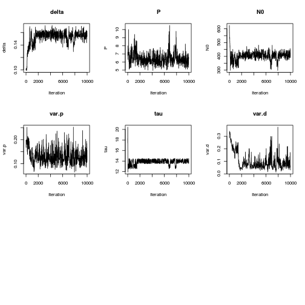

```
## Press <Enter> to see the next plot...
## [1] "The posterior densities"
```

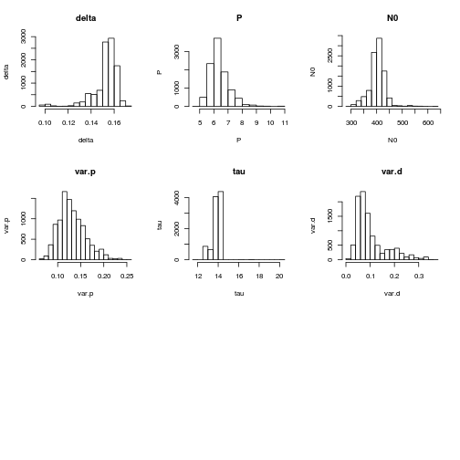

```
## Press <Enter> to see the next plot...
## [1] "Plotting the log-likelihood chain"
```

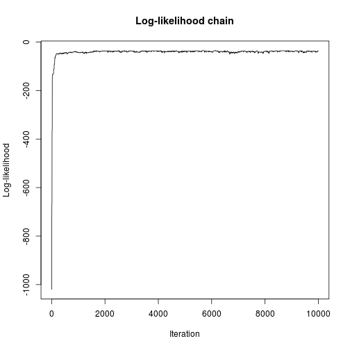

```
## Press <Enter> to see the next plot...
## [1] "Plotting correlation structure of the posterior sample"
```

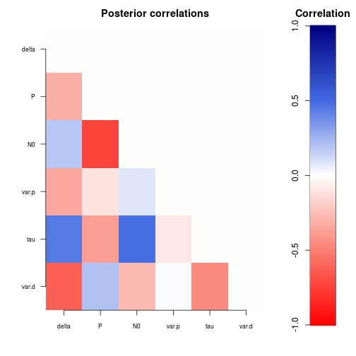

```
## Press <Enter> to see the next plot...
```

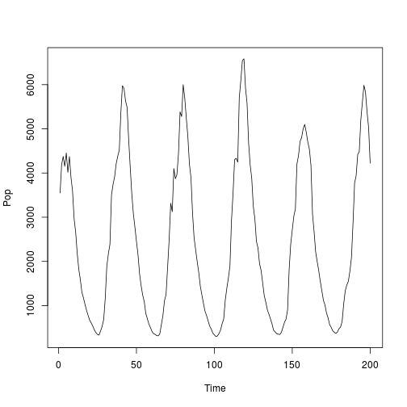

```r
data(blow_smcmc)
tmpTrans <- rep("exp", 6)
names(tmpTrans) <- names(blow_smcmc@param)
plot(blow_smcmc, trans = tmpTrans)
```

The package includes some of Nicholson (1954) experimental datasets, which can be loaded into the object:

```r
data(bf1)
blow_sl@data <- bf1$pop
blow_sl@extraArgs$obsData <- blow_sl@data
```

Then it is possible to fit the model using the experimental data by MCMC.

## Alpha-stable distribution

Let us consider a model that does not produce time series data: the alpha-stable distribution, as described in Nolan (2012). For a quick reference do `library("stableDist")` and `?rstable`. As a first step we need to wrap the function `rstable`, which simulates random variables from this distribution, into a function that fits the `synlik` framework:

```r
stableSimul <- function(param, nsim, extraArgs, ...)
{
  if( !is.loaded("stabledist") ) library(stabledist)

  # Some sanity check
  if( !( c("nObs") %in% names(extraArgs) ) ) stop("extraArgs should contain nObs")
  nObs <- extraArgs$nObs
  stopifnot( length(param) == 4 )
  param[c(1, 3)] <- exp(param[c(1, 3)])
  if(abs(param[1] - 1) < 0.01) stop("alpha == 1 is not allowed")

  # Actual simulation
  output <- rstable(nObs * nObs, alpha = param[1], beta = param[2], gamma = param[3], delta = param[4])

  return( matrix(output, nsim, nObs) )
}
```

We need also to set up a function that calculates the summary statistics, which in our case are 10 quantiles:

```r
stableStats <- function(x, extraArgs, ...){

  if (!is.matrix(x)) x <- matrix(x, 1, length(x))

  X0 <- t( apply(x, 1, quantile, probs = seq(0.1, 0.9, length.out = 10)) )

  unname(X0)
}
```

We then create a `synlik` object:

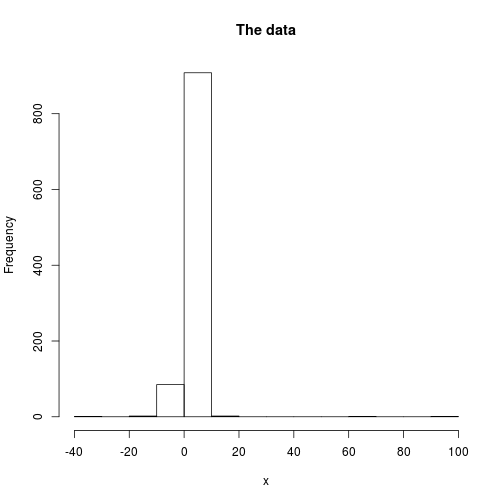

```r
stable_sl <- synlik( simulator = stableSimul,
                     summaries = stableStats,
                     param = c(alpha = log(1.5), beta = 0.1, gamma = log(1), delta = 2),
                     extraArgs = list("nObs" = 1000),
                     plotFun = function(input, ...) hist(input, xlab = "x", main = "The data", ...)
                     )
stable_sl@data <- simulate(stable_sl, seed = 67)
plot(stable_sl)
```

As we see from the histogram, the distribution is quite fat-tailed. As before, can then estimate the parameters by MCMC (you might want to increase `niter`):

```r
stable_sl <- smcmc(stable_sl,
                   initPar = c(alpha = log(1.7), beta = -0.1, gamma = log(1.3), delta = 1.5),
                   niter = 2,
                   burn = 0,
                   priorFun = function(input, ...) {
                                 dunif(input[1], log(1), log(2), log = TRUE) +
                                 dunif(input[2], -1, 1, log = TRUE)
                                 },
                   propCov = diag(c(0.1, 0.1, 0.1, 0.1))^2,
                   targetRate = 0.25,
                   nsim = 200)
# plot(stable_sl, trans = c("alpha" = "exp", "gamma" = "exp"))
```

```r
# slice(object = stable_sl,
#       ranges = list("alpha" = log(seq(1.2, 1.9, by = 0.05)),
#                     "beta"  = seq(-0.5, 0.5, by = 0.05),
#                     "gamma" = log(seq(0.5, 1.9, by = 0.05)),
#                     "alpha" = seq(1.1, 2.2, by = 0.05)),
#       param = stable_sl@param,
#       trans = list("alpha" = "exp", "gamma" = "exp"),
#       nsim = 1000,
#       multicore = TRUE,
#       ncores = 2)
```

We probably could do better by putting some more effort in choosing the summary statistics.

## References

- Simon N Wood. Statistical inference for noisy nonlinear ecological dynamic systems. Nature, 466(7310):1102–1104, 2010.
- Alexander J Nicholson. An outline of the dynamics of animal populations. Australian Journal of Zoology, 2(1):9–65, 1954.
- Diethelm Wuertz, Martin Maechler and Rmetrics core team members. (2013). stabledist: Stable Distribution Functions. R package version 0.6–6.